# Chapter 9 — Bivariate Data: Correlation and Beyond (R companion)

R/tidyverse translation of *Understanding Data by Alan Garfinkel and Yina Guo

Adrian Soto-Mota, MD, PhD, FACP.

2026-04-24

# Orientation

Chapter 9 (book pp. 448–508) is about measuring **association** between two variables: Pearson’s r, Spearman’s ρ, and mutual information. The book contains **no Python code listings** in this chapter. However, visual examples of the concepts in this chapter are provided below.

# §9.1 — Scatterplots come first *(book §9.1 “Bivariate data: two measurements”, p. 448)*

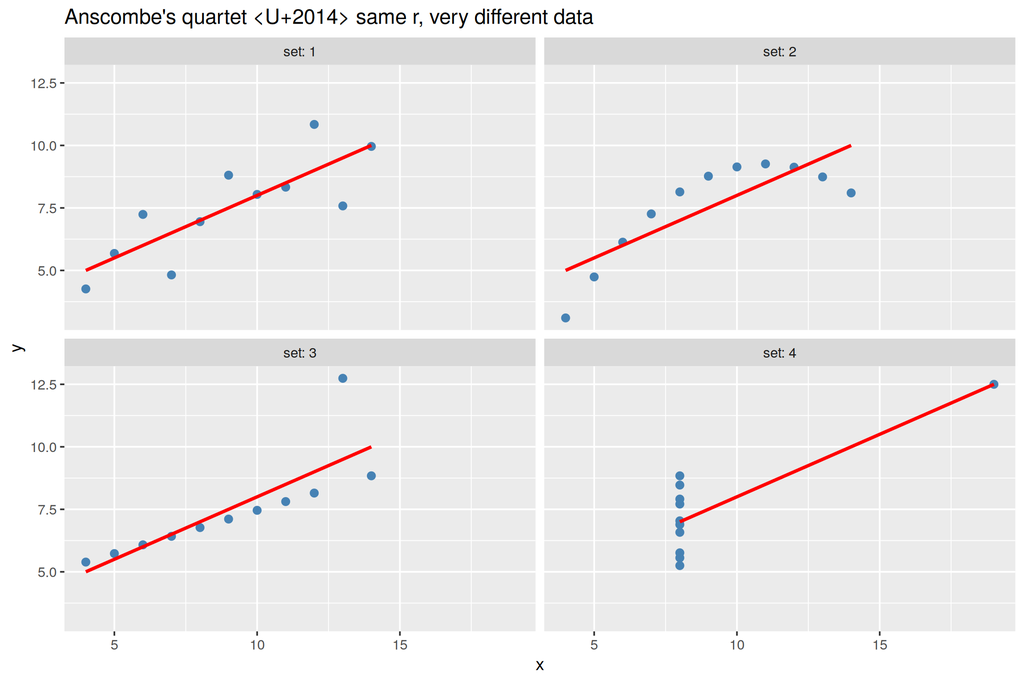

```r
# Anscombe's quartet: four data sets with identical r, means, SDs, and regression lines
data("anscombe")
anscombe_long <- anscombe |>
  pivot_longer(everything(),
               names_to = c(".value", "set"),
               names_pattern = "(.)(.)")

ggplot(anscombe_long, aes(x, y)) +
  geom_point(size = 2, color = "steelblue") +
  geom_smooth(method = "lm", se = FALSE, color = "red") +
  facet_wrap(~ set, labeller = label_both) +
  labs(title = "Anscombe's quartet — same r, very different data")
```

```r
anscombe_long |>
  group_by(set) |>
  summarise(r = cor(x, y), .groups = "drop")
```

```
## # A tibble: 4 x 2
##   set       r
##   <chr> <dbl>
## 1 1     0.816
## 2 2     0.816
## 3 3     0.816
## 4 4     0.817
```

All four sets have r ≈ 0.816. The scatterplots tell completely different stories.

# §9.2 — The correlation coefficient *(book p. 456)*

## Build it from scratch

Covariance, then correlation:

```r
# Use the first Anscombe dataset
d1 <- anscombe_long |> filter(set == "1")
x <- d1$x
y <- d1$y

# Covariance: average of (x − x̄)(y − ȳ)
cov_manual <- sum((x - mean(x)) * (y - mean(y))) / (length(x) - 1)
all.equal(cov_manual, cov(x, y))
```

```
## [1] TRUE
```

```r
# Pearson's r: covariance normalized by SD_x × SD_y
r_manual <- cov_manual / (sd(x) * sd(y))
all.equal(r_manual, cor(x, y))
```

```
## [1] TRUE
```

## When does r fail?

Non-linear, but strongly associated:

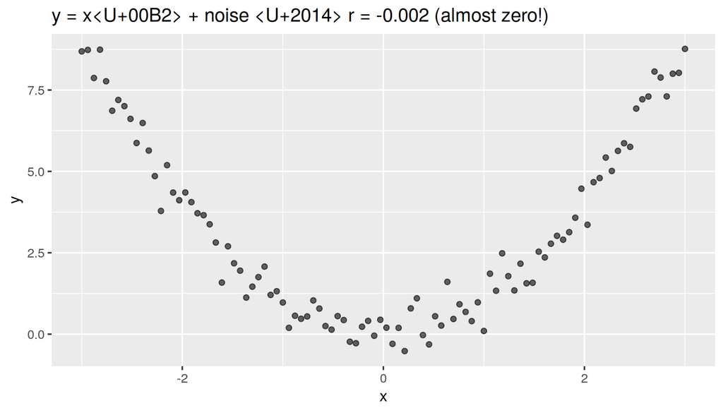

```r
set.seed(1)
x_nl <- seq(-3, 3, length.out = 100)
y_nl <- x_nl^2 + rnorm(100, sd = 0.5)

tibble(x = x_nl, y = y_nl) |>
  ggplot(aes(x, y)) +
  geom_point(alpha = 0.6) +
  labs(title = sprintf("y = x² + noise — r = %.3f (almost zero!)",
                       cor(x_nl, y_nl)))
```

r can be zero even when y is a deterministic function of x.

## Clusters create spurious r

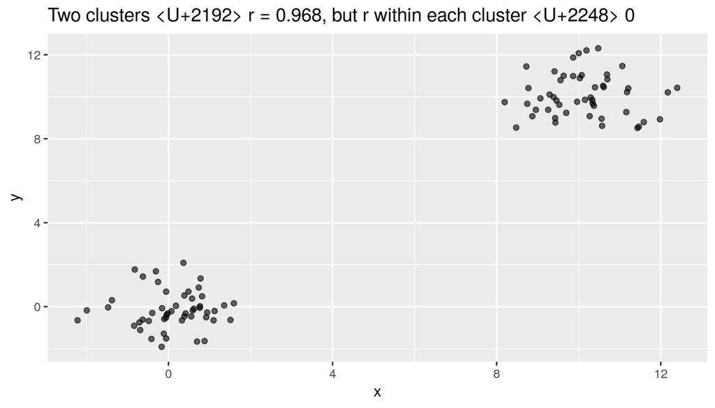

```r
set.seed(1)
cluster_data <- tibble(
  x = c(rnorm(50, 0,  1), rnorm(50, 10, 1)),
  y = c(rnorm(50, 0,  1), rnorm(50, 10, 1))
)

ggplot(cluster_data, aes(x, y)) +
  geom_point(alpha = 0.6) +
  labs(title = sprintf("Two clusters → r = %.3f, but r within each cluster ≈ 0",
                       cor(cluster_data$x, cluster_data$y)))
```

# §9.3 — Spearman correlation *(book p. 472)*

When the relationship is **monotonic but non-linear**, rank-transform first (Spearman’s ρ).

```r
# Create a strictly increasing but non-linear relationship
x <- runif(100, 0, 10)
y <- exp(x) + rnorm(100, sd = 100)   # exponential growth

c(Pearson  = cor(x, y, method = "pearson"),
  Spearman = cor(x, y, method = "spearman"))
```

```
##   Pearson  Spearman
## 0.7326481 0.8762316
```

Pearson is damaged by the curvature; Spearman captures the monotonic association directly.

# §9.4 — Significance by simulation *(book p. 477)*

Under H0, x and y are independent. Shuffle y while keeping x fixed; recompute r.

```r
# A weak-to-moderate linear relationship
n <- 50
x <- rnorm(n)
y <- 0.4 * x + rnorm(n, sd = sqrt(1 - 0.16))

obs_r <- cor(x, y)
obs_r
```

```
## [1] 0.3292067
```

```r
n_sim <- 10000
null_r <- numeric(n_sim)
for (i in seq_len(n_sim)) {
  null_r[i] <- cor(x, sample(y))    # shuffle y, recompute r
}

p_value <- mean(abs(null_r) >= abs(obs_r))
p_value
```

```
## [1] 0.0173
```

```r
# Compare to the theoretical test
cor.test(x, y)$p.value
```

```
## [1] 0.01957207
```

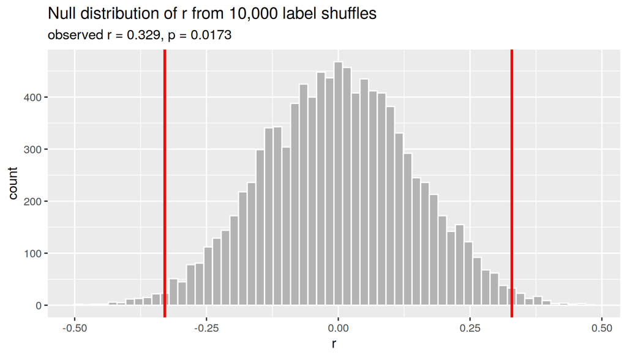

```r
tibble(r = null_r) |>
  ggplot(aes(r)) +
  geom_histogram(bins = 60, fill = "grey70", color = "white") +
  geom_vline(xintercept = c(-obs_r, obs_r),
             color = "red", linewidth = 1) +
  labs(title = "Null distribution of r from 10,000 label shuffles",
       subtitle = sprintf("observed r = %.3f, p = %.4f", obs_r, p_value))
```

# §9.5 — Bootstrap confidence interval for r *(book p. 482)*

```r
B <- 10000
boot_r <- numeric(B)
for (i in seq_len(B)) {
  idx       <- sample(seq_along(x), length(x), replace = TRUE)
  boot_r[i] <- cor(x[idx], y[idx])    # resample PAIRS
}
quantile(boot_r, c(0.025, 0.975))
```

```
##       2.5%      97.5%
## 0.08722546 0.54009332
```

Note the **paired resampling**: we resample `(x, y)` pairs so that the structure is preserved. Independently resampling x and y would break the correlation.

# §9.6 — The interpretation of correlation *(book p. 488)*

Remember: **correlation does not imply causation**. Classic confounders generate spurious correlations.

```r
# Both x and y driven by a common confounder z
n <- 200
z <- rnorm(n)              # hidden common cause (age, SES, calendar time...)
x <- 2 * z + rnorm(n)
y <- 3 * z + rnorm(n)

cor(x, y)                  # Large, significant, entirely due to z
```

```
## [1] 0.8547366
```

Without knowing `z`, we’d confidently claim `x → y`.

# §9.7 — Only an experiment establishes causation *(book §9.7 “Determining causation with an experiment”, p. 493)*

```r
# Randomize: now x is set by coin flip, not driven by z
n <- 200
z <- rnorm(n)
x_random <- sample(c(0, 1), n, replace = TRUE)
y <- 0.5 * x_random + 3 * z + rnorm(n)

cor(x_random, y)  # smaller and "honest"
```

```
## [1] 0.1713557
```

Random assignment breaks the link between `x` and every confounder `z`.

# §9.8 — Mutual information: a non-linear alternative *(book p. 496)*

Mutual information measures **any** dependency, not just linear.

```r
# Rough MI via binned histograms. For production use, see the `infotheo` package.
mutual_info <- function(x, y, n_bins = 10) {
  # discretize into n_bins
  bx <- cut(x, breaks = n_bins, labels = FALSE)
  by <- cut(y, breaks = n_bins, labels = FALSE)

  # joint and marginal probabilities
  p_xy <- prop.table(table(bx, by))
  p_x  <- prop.table(table(bx))
  p_y  <- prop.table(table(by))

  MI <- 0
  for (i in seq_len(nrow(p_xy))) {
    for (j in seq_len(ncol(p_xy))) {
      if (p_xy[i, j] > 0) {
        MI <- MI + p_xy[i, j] *
          log(p_xy[i, j] / (p_x[i] * p_y[j]))
      }
    }
  }
  MI
}

# Non-linear data (the parabola): Pearson is ≈ 0, MI catches the dependence
x_nl <- seq(-3, 3, length.out = 500)
y_nl <- x_nl^2 + rnorm(500, sd = 0.3)

tibble(
  measure      = c("Pearson r", "Spearman ρ", "Mutual information"),
  value        = c(cor(x_nl, y_nl),
                   cor(x_nl, y_nl, method = "spearman"),
                   mutual_info(x_nl, y_nl))
)
```

```
## # A tibble: 3 x 2
##   measure               value
##   <chr>                 <dbl>
## 1 Pearson r          -0.00524
## 2 Spearman ρ  -0.00316
## 3 Mutual information  1.17
```

MI > 0 even when r ≈ 0. The chapter discusses how to compare MI values across different mesh (bin) sizes and notes that — unlike r — MI is bounded by the entropy of the marginal, so normalization matters.

# Exercises

1. Replicate Anscombe’s dataset #2 (the parabola) and compute MI with `n_bins = 5`, `10`, `20`. How sensitive is MI to bin width?
2. Simulate a confounded triangle (`z → x, z → y`) with `n = 30, 100, 1000`. At which sample size does the spurious correlation become “significant” at α = 0.01? What does that tell you about large-n observational studies?
3. For the exponential example in §9.3, bootstrap CIs for both Pearson and Spearman. Which is narrower, and why is that NOT a reason to prefer one?